# Lab 10 - Trees, Bagging, RF, Boosting XGBoost

Jing Yu

2024-03-15

# Learning goals

- Perform classification and regression with tree-based methods in R
- Recognize that tree-based methods are capable of capturing non-linearities by splitting multiple times on the same variables
- Compare the performance of classification trees, bagging, random forests, and boosting for predicting heart disease based on the `heart` data.

# Lab description

For this lab we will be working with the `heart` dataset that you can download from [here](https://github.com/JSC370/JSC370-2024/blob/main/data/heart.csv)

### Setup packages

You should install and load `rpart` (trees), `randomForest` (random forest), `gbm` (gradient boosting) and `xgboost` (extreme gradient boosting).

```r
# install.packages(c("rpart", "rpart.plot", "randomForest", "gbm", "xgboost"))
```

### Load packages and data

```r
library(tidyverse)
library(rpart)
library(rpart.plot)
library(randomForest)
library(gbm)
library(xgboost)
library(caret)

heart <- read_csv("https://raw.githubusercontent.com/JSC370/JSC370-2024/main/data/heart.csv") |>
  mutate(
    AHD = 1 * (AHD == "Yes"),
    ChestPain = factor(ChestPain),
    Thal = factor(Thal)
  )

head(heart)
```

```
## # A tibble: 6 × 14
##     Age   Sex ChestPain    RestBP  Chol   Fbs RestECG MaxHR ExAng Oldpeak Slope
##   <dbl> <dbl> <fct>         <dbl> <dbl> <dbl>   <dbl> <dbl> <dbl>   <dbl> <dbl>
## 1    63     1 typical         145   233     1       2   150     0     2.3     3
## 2    67     1 asymptomatic    160   286     0       2   108     1     1.5     2
## 3    67     1 asymptomatic    120   229     0       2   129     1     2.6     2
## 4    37     1 nonanginal      130   250     0       0   187     0     3.5     3
## 5    41     0 nontypical      130   204     0       2   172     0     1.4     1
## 6    56     1 nontypical      120   236     0       0   178     0     0.8     1
## # ℹ 3 more variables: Ca <dbl>, Thal <fct>, AHD <dbl>
```

## Question 1: Trees

- Split the `heart` data into training and testing (70-30%)

```r
set.seed(100)
train<-sample(1:nrow(heart), round(0.7*nrow(heart)))
heart_train<-heart[train,]
heart_test<-heart[-train,]
```

- Fit a classification tree using rpart, plot the full tree. We are trying to predict AHD. Set minsplit = 10, minbucket = 3, and do 10 cross validations.

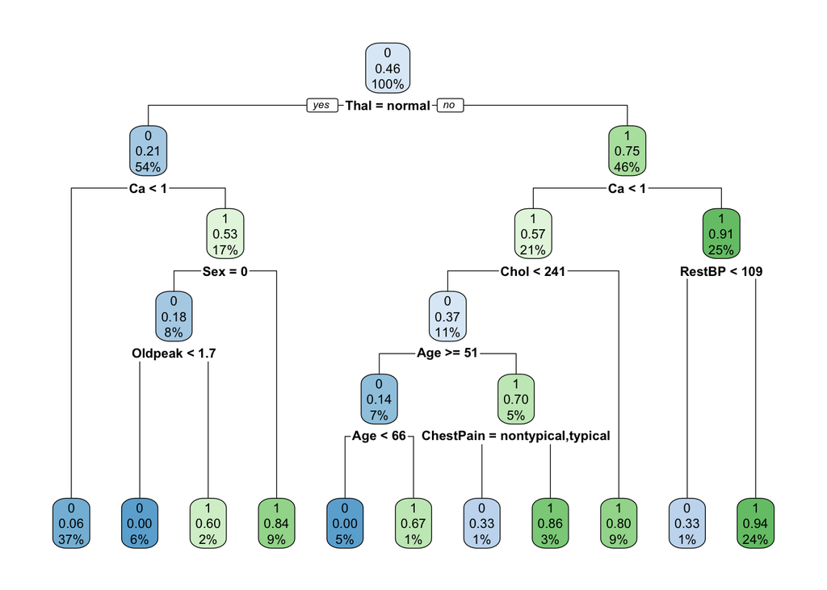

```r
heart_tree <- rpart(
  AHD~.,
  method = 'class',
  control = list(cp=0,
                 minbucket=3,
                 minsplit=10,
                 xval=10),
  data = heart_train
)
rpart.plot(heart_tree)
```

- Plot the complexity parameter table for an rpart fit and find the optimal cp

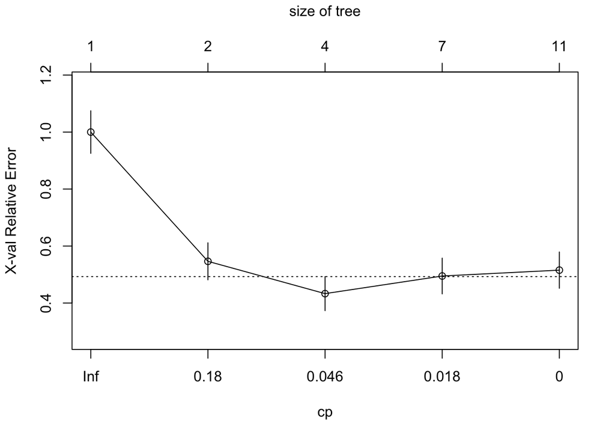

```r
plotcp(heart_tree)
```

```r
printcp(heart_tree)
```

```
##
## Classification tree:
## rpart(formula = AHD ~ ., data = heart_train, method = "class",
##     control = list(cp = 0, minbucket = 3, minsplit = 10, xval = 10))
##
## Variables actually used in tree construction:
## [1] Age       Ca        ChestPain Chol      Oldpeak   RestBP    Sex
## [8] Thal
##
## Root node error: 97/212 = 0.45755
##
## n= 212
##
##         CP nsplit rel error  xerror     xstd
## 1 0.505155      0   1.00000 1.00000 0.074782
## 2 0.067010      1   0.49485 0.54639 0.064998
## 3 0.030928      3   0.36082 0.43299 0.059829
## 4 0.010309      6   0.25773 0.49485 0.062821
## 5 0.000000     10   0.21649 0.51546 0.063724
```

```r
optimalcp = heart_tree$cptable[which.min(heart_tree$cptable[, 'xerror']), "CP"]
```

- Prune the tree

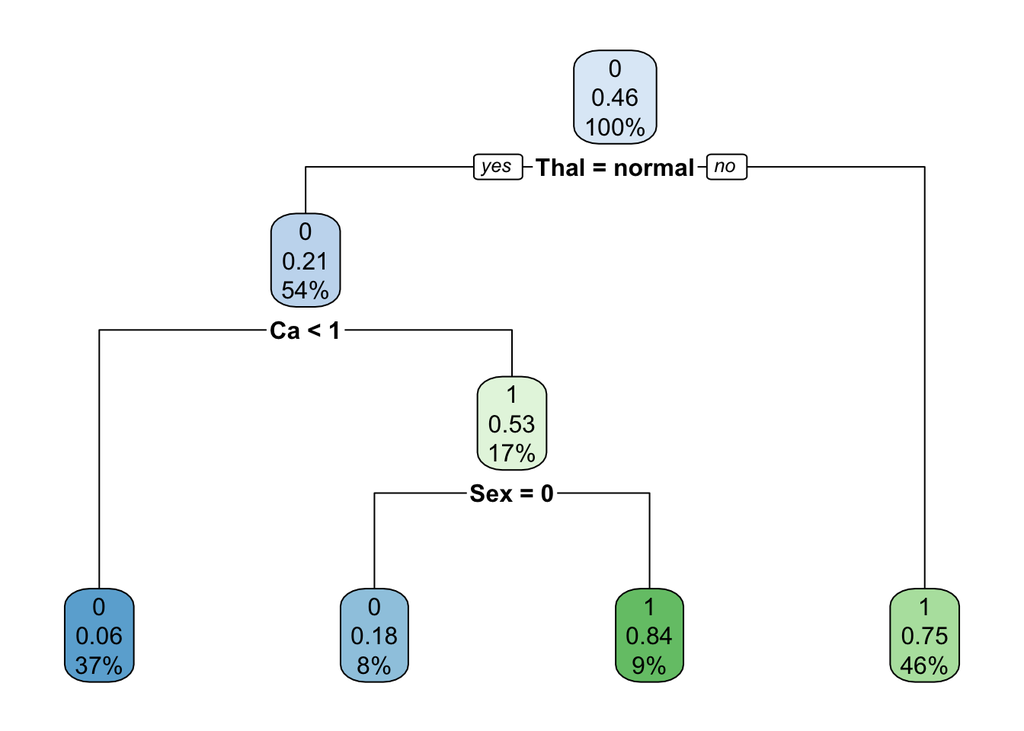

```r
heart_tree_prune<-prune(heart_tree, cp=optimalcp)
rpart.plot(heart_tree_prune)
```

- Compute the test misclassification error

```r
heart_pred<-predict(heart_tree_prune, heart_test)
heart_pred <- as.data.frame(heart_pred)
heart_pred$AHD <- ifelse(heart_pred$'1'>0.5, 1, 0)

confmatrix_table <- table(true=heart_test$AHD, predicted=heart_pred$AHD)
confmatrix_table
```

```
##     predicted
## true  0  1
##    0 33 16
##    1 11 31
```

```r
mis_error = (11+16) / (33+16+11+31)
mis_error
```

```
## [1] 0.2967033
```

```r
mis_error = (confmatrix_table[1, 2]+confmatrix_table[2, 1]) /
  (confmatrix_table[1, 2]+confmatrix_table[2, 1]+confmatrix_table[1, 1]+confmatrix_table[2, 2])
mis_error
```

```
## [1] 0.2967033
```

- Fit the tree with the optimal complexity parameter to the full data (training + testing)

```r
heart_tree<-rpart(
  AHD~.,
  data = heart,
  method = 'class',
  control = list(cp=optimalcp)
)
```

- Find the Out of Bag (OOB) error for tree

```r
heart_tree$cptable
```

```
##           CP nsplit rel error    xerror       xstd
## 1 0.47482014      0 1.0000000 1.0000000 0.06240124
## 2 0.04676259      1 0.5251799 0.5755396 0.05520283
## 3 0.03092784      5 0.3381295 0.4676259 0.05140544
```

```r
min(heart_tree$cptable[, 'xerror'])* nrow(heart)
```

```
## [1] 141.6906
```

## Question 2: Bagging, Random Forest

- Compare the performance of classification trees (above), bagging, random forests for predicting heart disease based on the `heart` data.
- Use the training and testing sets from above. Train each of the models on the training data and extract the cross-validation (or out-of-bag error for bagging and Random forest).
- For bagging use `randomForest` with `mtry` equal to the number of features (all other parameters at their default values). Generate the variable importance plot using `varImpPlot` and extract variable importance from the `randomForest` fitted object using the `importance` function.

```r
heart_bag<-randomForest(
  as.factor(AHD)~.,
  data = heart_train,
  mtry = ncol(heart_train) - 1,
  na.action = na.omit
)
# oob error rate
sum(heart_bag$err.rate[, 1])
```

```
## [1] 105.5319
```

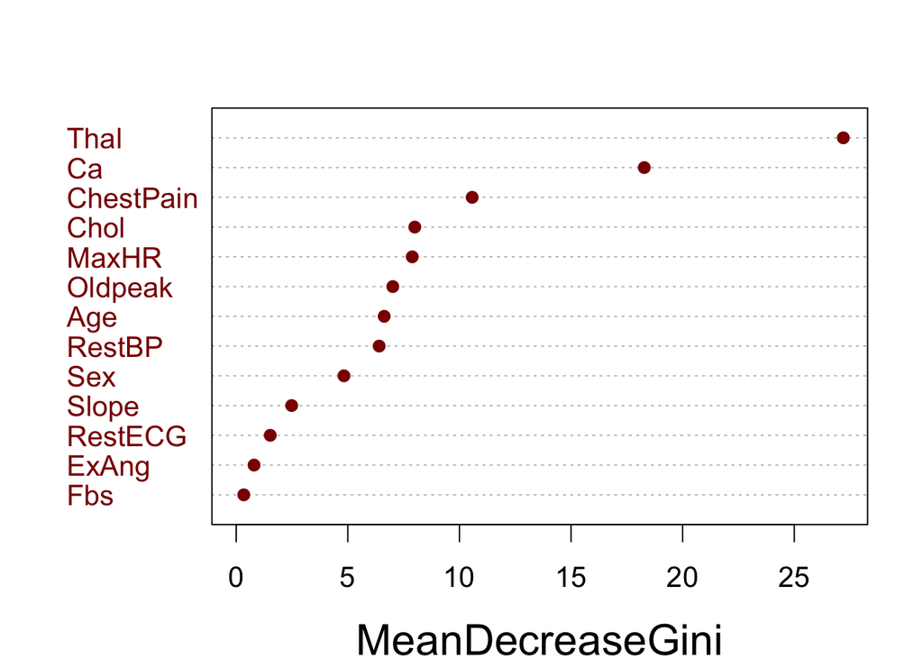

```r
varImpPlot(
  heart_bag,
  cex.lab = 1.5, cex.axis = 2, cex = 1.3,
  n.var = 13, col = "red4", main = "", pch = 16)
```

```r
importance(heart_bag)
```

```
##           MeanDecreaseGini
## Age              6.6289966
## Sex              4.8261281
## ChestPain       10.5704033
## RestBP           6.4047949
## Chol             8.0007628
## Fbs              0.3399730
## RestECG          1.5256120
## MaxHR            7.8865991
## ExAng            0.7991887
## Oldpeak          7.0150886
## Slope            2.4841198
## Ca              18.2800544
## Thal            27.1981235
```

- For random forests use `randomForest` with the default parameters. Generate the variable importance plot using `varImpPlot` and extract variable importance from the `randomForest` fitted object using the `importance` function.

```r
heart_rf <- randomForest(
  as.factor(AHD)~.,
  data = heart_train,
  na.action = na.omit
)
#oob error rate
sum(heart_rf$err.rate[, 1])
```

```
## [1] 85.86587
```

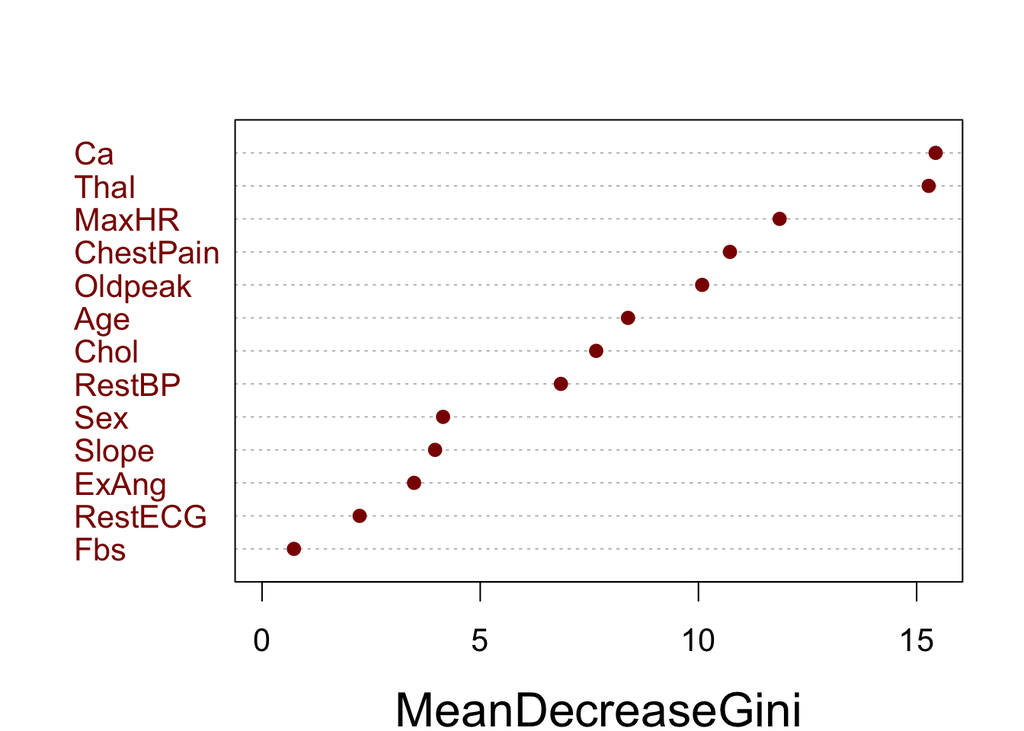

```r
varImpPlot(
  heart_rf,
  cex.lab = 1.5, cex.axis = 2, cex = 1.3,
  n.var = 13, col = "red4", main = "", pch = 16)
```

```r
importance(heart_rf)
```

```
##           MeanDecreaseGini
## Age               8.385621
## Sex               4.148360
## ChestPain        10.721855
## RestBP            6.848034
## Chol              7.656347
## Fbs               0.730349
## RestECG           2.235732
## MaxHR            11.860047
## ExAng             3.483556
## Oldpeak          10.085044
## Slope             3.965198
## Ca               15.434713
## Thal             15.275720
```

# Question 3: Boosting

- For boosting use `gbm` with `cv.folds=5` to perform 5-fold cross-validation, and set `class.stratify.cv` to `AHD` (heart disease outcome) so that cross-validation is performed stratifying by `AHD`. Plot the cross-validation error as a function of the boosting iteration/trees (the `$cv.error` component of the object returned by `gbm`) and determine whether additional boosting iterations are warranted. If so, run additional iterations with `gbm.more` (use the R help to check its syntax). Choose the optimal number of iterations. Use the `summary.gbm` function to generate the variable importance plot and extract variable importance/influence (`summary.gbm` does both). Generate 1D and 2D marginal plots with `gbm.plot` to assess the effect of the top three variables and their 2-way interactions.

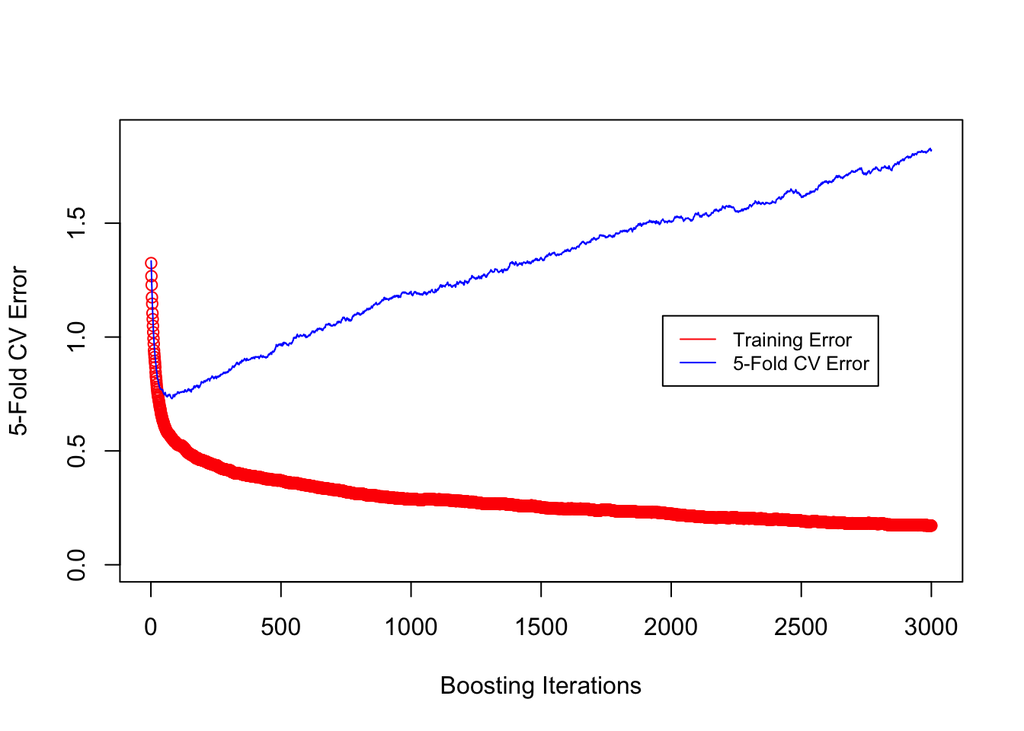

```r
heart_boost = gbm(AHD ~ .,
                  data = heart_train,
                  distribution = "bernoulli",
                  n.trees = 3000,
                  cv.folds = 5,
                  class.stratify.cv = TRUE
                  )

# make chart pretties y-axis
y_lim_max <- max(max(heart_boost$train.error), max(heart_boost$cv.error)) + 0.05
plot(heart_boost$train.error, xlab = "Boosting Iterations", ylab = "5-Fold CV Error",
     ylim = c(0, y_lim_max), col = "red")
lines(heart_boost$cv.error, col = 'blue')
legend("right", legend = c("Training Error", "5-Fold CV Error"),
       col = c("red", "blue"), lty = 1, cex = 0.8, inset = c(0.1, 0))
```

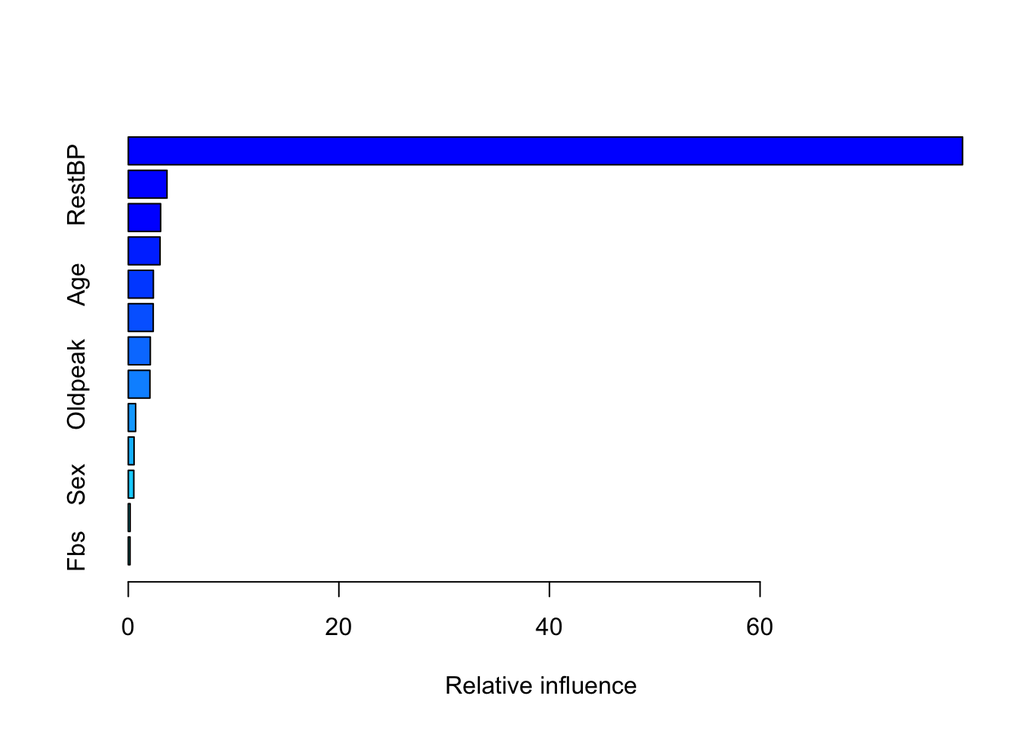

```
##                 var    rel.inf
## Thal           Thal 79.2334312
## RestBP       RestBP  3.6753190
## ChestPain ChestPain  3.0688337
## Ca               Ca  3.0177867
## Age             Age  2.3816737
## MaxHR         MaxHR  2.3680682
## Chol           Chol  2.0908658
## Oldpeak     Oldpeak  2.0545979
## Slope         Slope  0.6989908
## RestECG     RestECG  0.5474058
## Sex             Sex  0.5224477
## ExAng         ExAng  0.1749698
## Fbs             Fbs  0.1656095
```

```r
summary(heart_boost)
```

## Question 4: Gradient Boosting

Evaluate the effect of critical boosting parameters (number of boosting iterations, shrinkage/learning rate, and tree depth/interaction). In `gbm` the number of iterations is controlled by `n.trees` (default is 100), the shrinkage/learning rate is controlled by `shrinkage` (default is 0.001), and interaction depth by `interaction.depth` (default is 1).

Note, boosting can overfit if the number of trees is too large. The shrinkage parameter controls the rate at which the boosting learns. Very small $\lambda$ can require using a very large number of trees to achieve good performance. Finally, interaction depth controls the interaction order of the boosted model. A value of 1 implies an additive model, a value of 2 implies a model with up to 2-way interactions, etc. the default is 1.

- Set the seed and train a boosting classification with `gbm` using 10-fold cross-validation (`cv.folds=10`) on the training data with `n.trees = 5000`, `shrinkage = 0.001`, and `interaction.depth =1`. Plot the cross-validation errors as a function of the boosting iteration and calculate the test MSE.

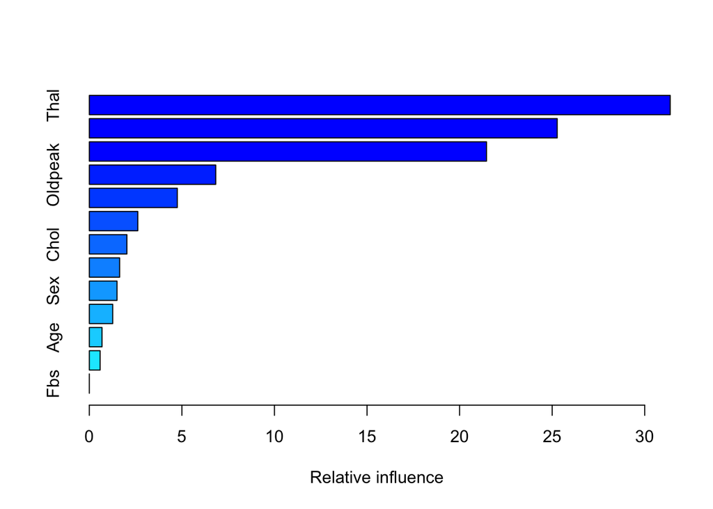

```
##                 var    rel.inf
## Thal           Thal 31.3775655
## Ca               Ca 25.2736696
## ChestPain ChestPain 21.4553464
## Oldpeak     Oldpeak  6.8284149
## MaxHR         MaxHR  4.7532227
## Slope         Slope  2.6174023
## Chol           Chol  2.0295597
## ExAng         ExAng  1.6373708
## Sex             Sex  1.4958024
## RestECG     RestECG  1.2638684
## Age             Age  0.6856281
## RestBP       RestBP  0.5821491
## Fbs             Fbs  0.0000000
```

```r
set.seed(301)
heart_boost = gbm(AHD ~ ., data = heart[train, ], distribution = "bernoulli", n.trees = 5000, interaction.depth = 1, shrinkage = 0.001, cv.folds = 10, class.stratify.cv = TRUE)

summary(heart_boost)
```

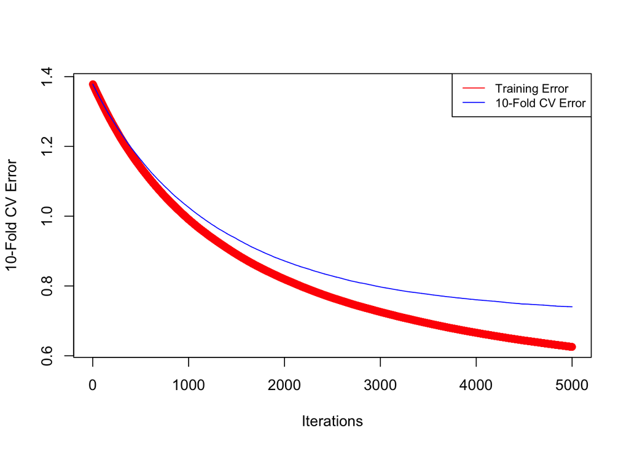

```r
plot(heart_boost$train.error, xlab = "Iterations", ylab = "10-Fold CV Error", col = "red")
lines(heart_boost$cv.error, col = 'blue')
legend("topright", legend = c("Training Error", "10-Fold CV Error"),
       col = c("red", "blue"), lty = 1, cex = 0.8)
```

```r
#calculate MSE
# predict with test data and mse
yhat_boost <- predict(heart_boost,
                      newdata = heart_test,
                      n.trees = 5000,
                      type = "response")

mse_test <- mean((yhat_boost - heart_test$AHD)^2)
print(mse_test)
```

```
## [1] 0.13951
```

- Repeat the above using the same seed and `n.trees=5000` with the following 3 additional combination of parameters: a) `shrinkage = 0.001`, `interaction.depth = 2`; b) `shrinkage = 0.01`, `interaction.depth = 1`; c) `shrinkage = 0.01`, `interaction.depth = 2`.

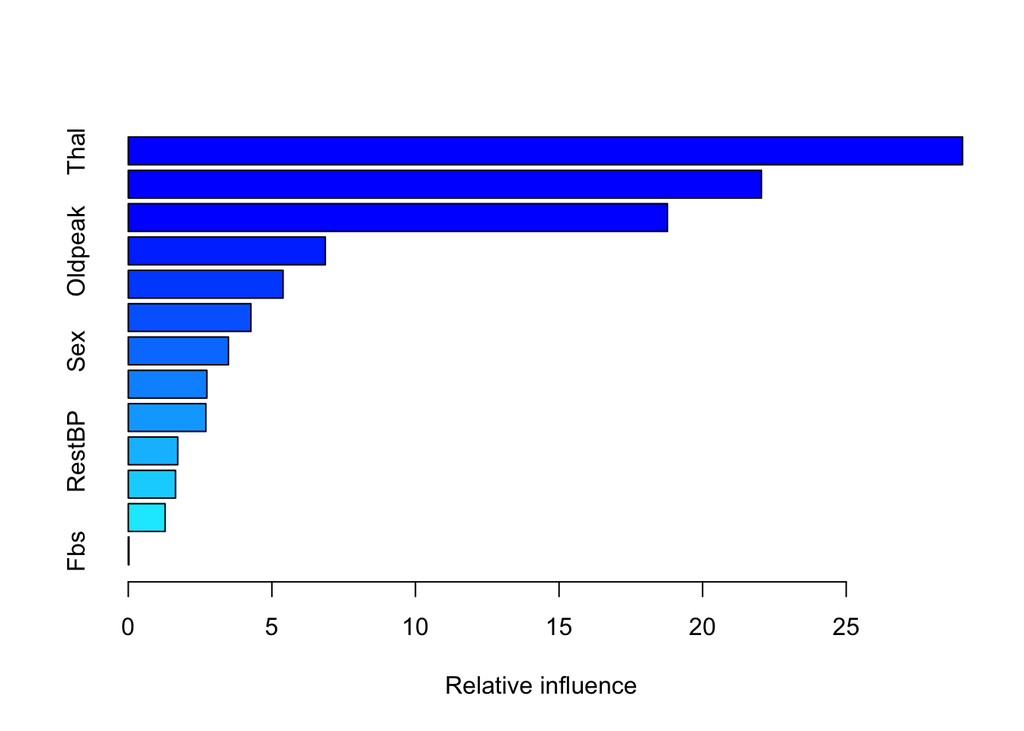

```
##                 var     rel.inf
## Thal           Thal 29.05245402
## Ca               Ca 22.04844443
## ChestPain ChestPain 18.77691337
## Oldpeak     Oldpeak  6.86149003
## MaxHR         MaxHR  5.38979251
## Chol           Chol  4.27020820
## Sex             Sex  3.48756966
## Slope         Slope  2.73707021
## Age             Age  2.70207881
## RestBP       RestBP  1.72315144
## RestECG     RestECG  1.64597329
## ExAng         ExAng  1.28181105
## Fbs             Fbs  0.02304299
```

```r
set.seed(301)
# build 3 more trees and repeat above

# (a)
set.seed(301)
heart_boost = gbm(AHD ~ ., data = heart[train, ], distribution = "bernoulli", n.trees = 5000, interaction.depth = 2, shrinkage = 0.001, cv.folds = 10, class.stratify.cv = TRUE)

summary(heart_boost)
```

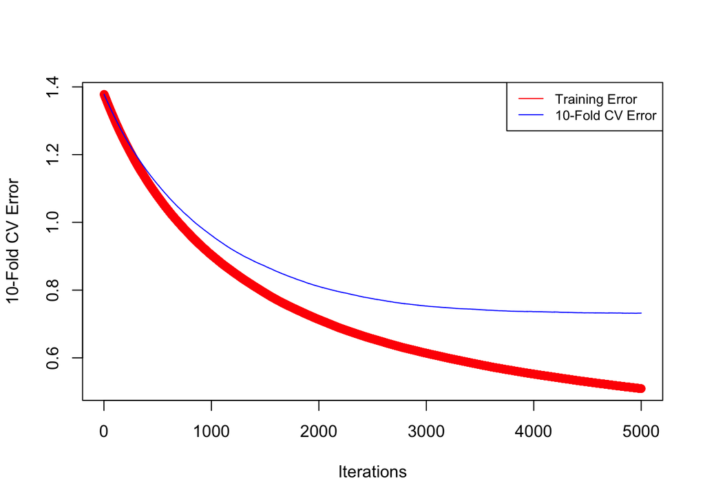

```r
plot(heart_boost$train.error, xlab = "Iterations", ylab = "10-Fold CV Error", col = "red")
lines(heart_boost$cv.error, col = 'blue')
legend("topright", legend = c("Training Error", "10-Fold CV Error"),
       col = c("red", "blue"), lty = 1, cex = 0.8)
```

```r
yhat_boost <- predict(heart_boost,
                      newdata = heart_test,
                      n.trees = 5000,
                      type = "response")
mse_test <- mean((yhat_boost - heart_test$AHD)^2)
print(mse_test)
```

```
## [1] 0.1431155
```

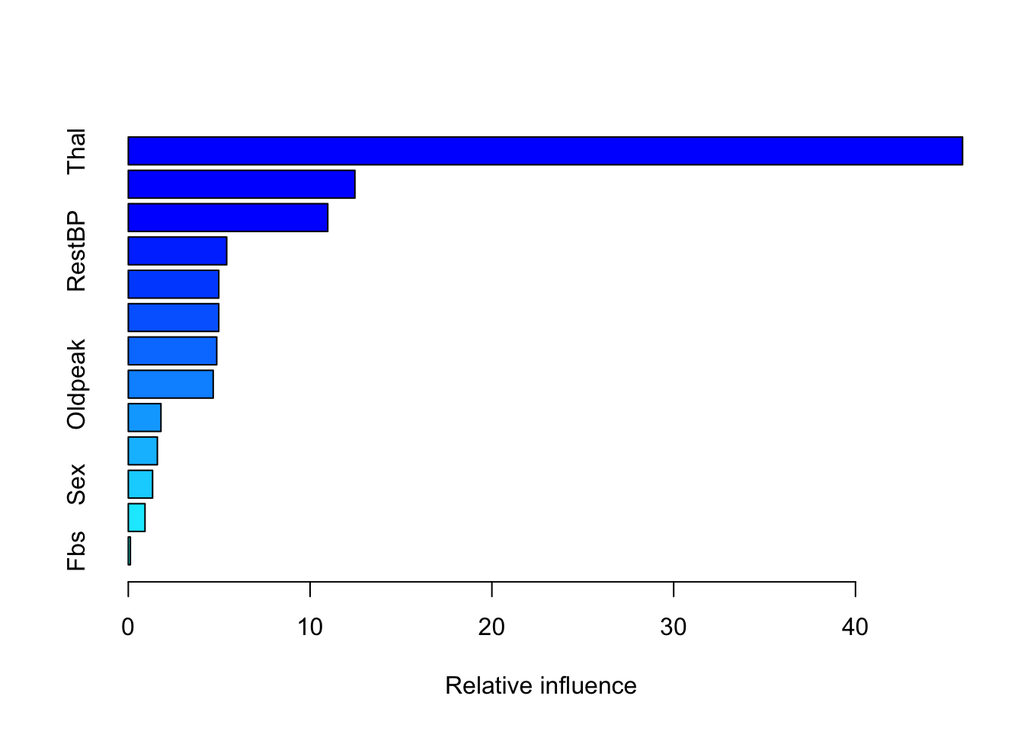

```
##                 var    rel.inf
## Thal           Thal 45.8901504
## Ca               Ca 12.4656099
## ChestPain ChestPain 10.9734657
## RestBP       RestBP  5.4136853
## MaxHR         MaxHR  4.9767248
## Age             Age  4.9755769
## Chol           Chol  4.8657691
## Oldpeak     Oldpeak  4.6710647
## Slope         Slope  1.7975086
## RestECG     RestECG  1.5995173
## Sex             Sex  1.3366905
## ExAng         ExAng  0.9196259
## Fbs             Fbs  0.1146110
```

```r
# (b)
set.seed(301)
heart_boost = gbm(AHD ~ ., data = heart[train, ], distribution = "bernoulli", n.trees = 5000, interaction.depth = 1, shrinkage = 0.01, cv.folds = 10, class.stratify.cv = TRUE)

summary(heart_boost)
```

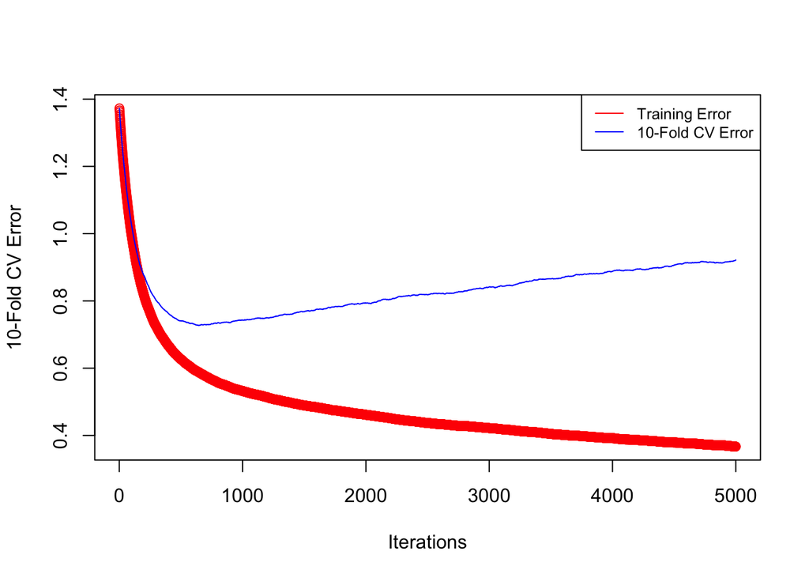

```r
plot(heart_boost$train.error, xlab = "Iterations", ylab = "10-Fold CV Error", col = "red")
lines(heart_boost$cv.error, col = 'blue')
legend("topright", legend = c("Training Error", "10-Fold CV Error"),
       col = c("red", "blue"), lty = 1, cex = 0.8)
```

```r
yhat_boost <- predict(heart_boost,
                      newdata = heart_test,
                      n.trees = 5000,
                      type = "response")
mse_test <- mean((yhat_boost - heart_test$AHD)^2)
print(mse_test)
```

```
## [1] 0.1600821
```

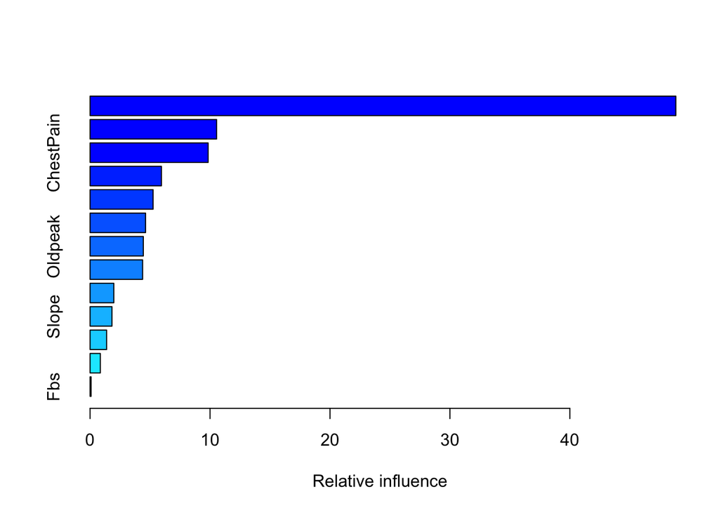

```
##                 var     rel.inf
## Thal           Thal 48.83589962
## Ca               Ca 10.54741104
## ChestPain ChestPain  9.84369261
## MaxHR         MaxHR  5.94831191
## Chol           Chol  5.25436947
## Age             Age  4.62625702
## Oldpeak     Oldpeak  4.43890614
## RestBP       RestBP  4.38003723
## Sex             Sex  1.97875714
## Slope         Slope  1.82510070
## RestECG     RestECG  1.38018303
## ExAng         ExAng  0.85566738
## Fbs             Fbs  0.08540671
```

```r
# (c)
set.seed(301)
heart_boost = gbm(AHD ~ ., data = heart[train, ], distribution = "bernoulli", n.trees = 5000, interaction.depth = 2, shrinkage = 0.01, cv.folds = 10, class.stratify.cv = TRUE)

summary(heart_boost)
```

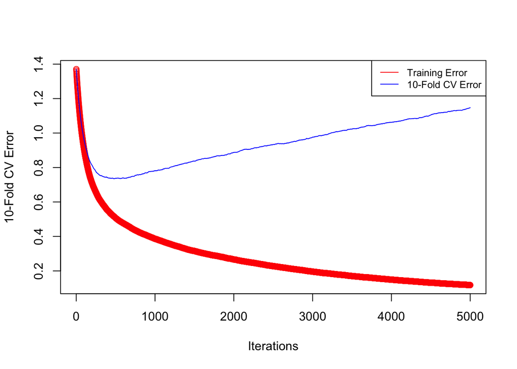

```r
plot(heart_boost$train.error, xlab = "Iterations", ylab = "10-Fold CV Error", col = "red")
lines(heart_boost$cv.error, col = 'blue')
legend("topright", legend = c("Training Error", "10-Fold CV Error"),
       col = c("red", "blue"), lty = 1, cex = 0.8)
```

```r
yhat_boost <- predict(heart_boost,
                      newdata = heart_test,
                      n.trees = 5000,
                      type = "response")
mse_test <- mean((yhat_boost - heart_test$AHD)^2)
print(mse_test)
```

```
## [1] 0.1652986
```

## Question 5: Extreme Gradient Boosting

Training an xgboost model with `xgboost` and perform a grid search for tuning the number of trees and the maxium depth of the tree. Also perform 10-fold cross-validation and determine the variable importance. Finally, compute the test MSE.

```r
train_control = caret::trainControl(method = "cv", number = 10, search ="grid")

tune_grid<-  expand.grid(max_depth = c(1, 3, 5, 7), #larger makes model more complex and potentially overfit
                        nrounds = (1:10)*50, # number of trees
                        # default values below
                        eta = c(0.01,0.1,0.3), # learning rate (equivalent to shrinkage)
                        gamma = 0, #Minimum loss reduction required to make a further partition on a leaf node of the tree. The larger gamma is, the more conservative the algorithm will be.
                        subsample = 1,
                        min_child_weight = 1,
                        colsample_bytree = 0.6 #specify the fraction of columns to be subsampled
                        )

heart_xgb<-caret::train(
  AHD ~ .,
  data = heart_train,
  na.action = na.omit,
  method = "xgbTree",
  trControl = train_control,
  tuneGrid = tune_grid,
  verbosity = 0
)
```

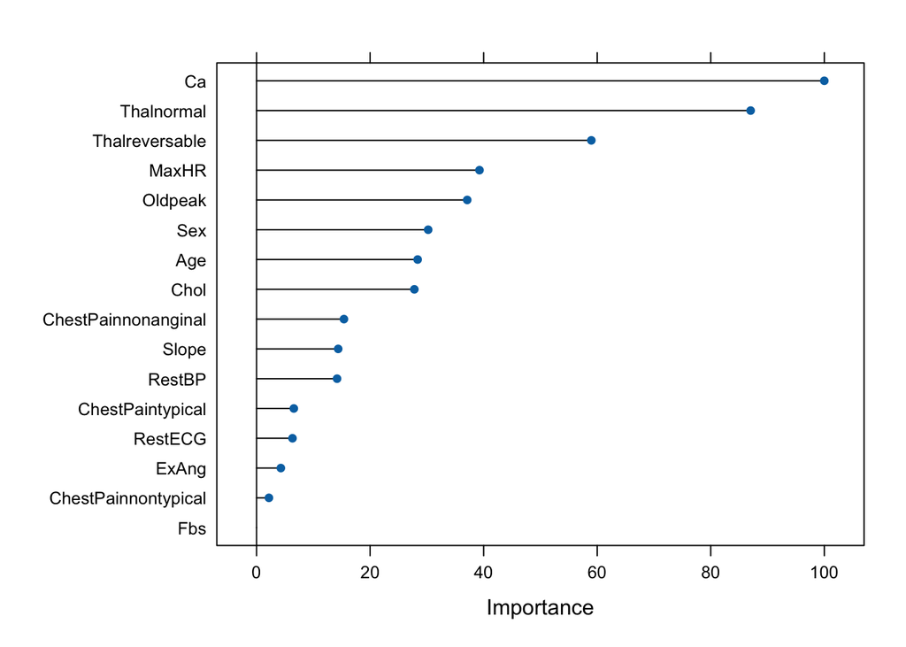

```r
varimp <- varImp(heart_xgb)
plot(varimp)
```

```r
# predict using the test data compute mse
predictions <- predict(heart_xgb, newdata = heart_test)
mse_test <- mean((predictions - heart_test$AHD)^2)
print(mse_test)
```

```
## [1] 0.1522401
```

# Deliverables

1. Questions 1-5 answered, pdf or html output uploaded to quercus